# Forecasting US Inflation (1 year)

William Stevenson

04-10-2022

$~$

## Introduction

Inflation is one of the trickiest things in economics and business to pin down. How inflation moves year to year,  
or even quarter to quarter, is a factor of so many economic forces from nominal output of goods and the nominal  
amount of money in the economy to unemployment rate and expectations of future inflation. How inflation moves and  
by how much is also of concern to practically everyone who participates in the economy. Businesses need to know  
how prices move to keep on top of profits. Citizens need to be able to plan for how much value their savings will  
have in the future.  
Traditional forecasts have either stuck to legacy specifications of the Phillips Curve that utilize unemployment  
rate and lags of inflation. Other forecasts have gone the other direction and included hundreds of variables to try  
and improve forecasts accuracy. This paper attempts to find a better model for forecasting “U.S” inflation  
using the traditional model specification for the Phillips Curve while slotting in different variables for  
unemployment.  
In the next section, the paper will dive into data collection methodology and data mutation.

## Data Collection and Mutation

To aid in these quest’s for information, economist and forecasters have been creating models to estimate what  
inflation in future periods will be based on other variables. The data used to build these models was  
pulled from the Federal Reserve’s Economic Data (F.R.E.D) database. The first variable retrived was Personal Consumption Expenditures (Price index reported monthly and seasonally adjusted by Bureau of Economic Analysis).  
This metric is the preferred measure for inflation by the Federal Reserve. For this reason we will be using  
it as our measure for calculating inflation and our lagged variables of inflation for all of our models.  
In order to convert the data from an Index to percentage change, it was required to take PCEPI and divide it by  
the lag of PCEPI, take the natural log of that, and multiply that number by 1200.

The next variable that was utilized was the Unemployment rate gathered from FRED (UNRATE). This data set is provided
by the Bureau of Labor Statistics and is reported monthly and already seasonally adjusted.(Series officially from
‘Current Population Survey’). This data is gathered from all 50 states and the District of Columbia, restricting
observations to persons 16 years or older. This data set was already provided in a percent format, so to mutate
the data into percentage of change of Unemployment rate was as simple as subtracting each observation from its
lag.
The next variable required in our analysis is the Capacity Utilization: Total Index (TCU) from FRED. This data
is produced by the Board of Governors of the Federal Reserve System and is reported monthly and already
seasonally adjusted. Capacity Utilization in essence measures the percent of total resources utilized by
corporations and factories to produce goods. This metric is created for 89 different industries, however this
metric in particular is taking into account all of them. Similar to Unemployment rate, our data is already in
percent form so to mutate them to percentage change is easy enough. Simply subtract each observation from its
lag and it is all ready.
Next we fetch the Industrial Production Index (INDPRO) from FRED. This metric is also reported by the Board
of Governors of the Federal Reserve System and is reported monthly, seasonally adjusted and in an index.
For this reason, we mutate our data by dividing each observation by its lag, taking the natural log of that
and multiplying by 1200. This will result in percentage changes from each observation to the next.
Next, we need to grab is the Industrial Production Index for Manufacturing from FRED. (IPMAN)
This data set has been created by the Board of Governors of the Federal Reserve System and is reported monthly,
seasonally adjusted and in an index. To mutate our data into percentage changes, we simply have to divide each
observation by its lag, take the log, and multiply by 1200.
Finally, we create our variable for our estimation of inflation one-year ahead. This will end up being the
variable that we run our regression/forecasts on where $dinfl12 = (\pi^{12}_t - \pi_{t-12})$ where
$\pi^{12}_t$ is the summation of 12 ordered lags divided by their previous lagged observation. More formally as:
$$\pi^{12}_t = \phi + \beta(B)\Delta_{\pi_{t-12}} + \gamma(B)_{u_{t-12}} + \pi_{t-12} + \varepsilon_t$$
where $\beta(B)$ and $\gamma(B)$ are our order of lag polynomials which we have decided to be 12.
As we start from $t-12$, all of our lags start off at $t-12$ and go backwards to $t-23$. In essence, we are
going to end up predicting what current inflation should look like today using data on inflation from last year
so that we can train our model in-sample with available data. This fitting will then be extrapolated past our
available data set to provide an actual one-year forecast for “U.S” Inflation.

## Reasons for Variable Choice and Transformations

The first of our variables (PCEPI) was selected to get a measure for inflation. Inflation after all is the  
is the overall measure of how the purchasing power of of money changes over time. Generally, as inflation rises  
each dollar as less purchasing power and therefore, prices will increase. PCEPI measures how the price of household  
goods and services changes. We can obtain inflation by dividing each observation by its previous observation,  
taking the log and multiply by 1200.  
Next, the purpose of this analysis is to see if improvements can be made on using the Phillips Curve using variables  
other than unemployment. Naturally, we need to estimate the Phillips Curve using Unemployment to have an estimation  
that we can try to beat. Also makes sense to include in our ensemble model as unemployment theoretically influences  
inflation very heavily. During times of low unemployment, demand for labor exceeds the supply of it. Employers  
will have to bid up wages to attract employees; forcing the cost of inputs to go up and by extension, the price of  
the downstream product or service. This will propagate into lower demand for these products and services, eventually  
putting pressure on firms to lower prices later. The opposite occurs when unemployment is high. Those searching for  
work will not accept less than a reasonable market wage and ever so slowly, prices fall.  
This is how the Phillips Curve substantiation goes and for a long time, was widely accepted. But can we do better?  
First step back and think, what exactly determines the purchasing power of currency? Most economist would agree that  
it is based on the nominal amount of goods in an economy and the nominal amount of money supply in an economy.  
Generally, when you increase the amount of actual money floating around in an economy, but do not change the actual  
amount of goods in that economy, the purchasing power of each of those units of currency falls (too much money  
chasing too few goods). So, it would make sense to bring in some measures for how to production of goods/services  
has been changing over time to forecast how inflation has been changing over time.  
For these reasons, the measures of output capability of the economy should be useful in predicting inflation  
with our forecasts. If the production of goods and services is growing, it is likely that the demand for these  
goods and services is growiing as well and putting upwards pressure on inflation. On the other hand, if production  
of goods and services are falling, it is likely that the demand for these goods and services is falling, putting  
downwards pressure on inflation.  
Next, we move on to discuss model specification.  
To see the entire code and html file, follow this link. [link](https://will-stevenson813.github.io)

## Formulation of Model

The first model that is estimated is the classic Phillips curve using the specification:
$$\pi^{12}_t - \pi_{t-12} = \phi + \beta(B)\Delta_{\pi_{t-12}} + \gamma(B)_{u_{t-12}} + \varepsilon_t$$
where $\pi^{12}_t = 100ln(P_t/P_{t-12})$, $\pi_{t-12} = 1200ln(P_{t-12}/P_{t-13})$, $P_t$ is the price level
measured by our variable PCEPI, $u_t$ is the annualized unemployment rate measured by our variable UNRATE.
$\beta(B)$ and $\gamma(B)$ are our order of lag polynomials which we have decided to be 12.
The reason for this being that while at steady-state, with all shocks equaling zero and with all other variables
converging on some equilibrium value, the 1-year ahead forecast for the inflation rate is:
$$\lim_{t\to\infty} \pi^{12}_t = 12\overline{\pi} = \phi + \overline{\pi} + \gamma(1)\overline{u}$$
where $\overline{\pi}$ and $\overline{u}$ are the steady-state level of inflation and unemployment rate.
To see why this is useful, let us rewrite the model as:

$$\pi^{12}_t = \phi + \pi_{t-12} + \sum_{i=0}^{11}\beta_i(\pi_{t-12-i}-\pi_{t-12-1-i}) + \gamma(B)u_{t-12} + \varepsilon_t$$
with $\beta(B)$ and $\gamma(B)$ are the $12^{th}$-order polynomials in the lag operator $B$.
This can be rewritten as:

$$\pi^{12}_t = \phi + (1 + \beta_0)\pi_{t-12} + (\beta_1 - \beta_0)\pi_{t-13} + (\beta_2 - \beta_1)\pi_{t-14}...+ (\beta_{11}-\beta_{10})\pi_{t-23} - \beta_{11}\pi_{t-24} + \gamma(B)u_{t-24} + \varepsilon_t$$
and then further reduced to:
$$\pi^{12}_t = (\mu_o + \mu_1B + \mu_2B^2 + \mu_3B^3 + \mu_4B^4... + \mu_{12}B^{12})\pi_{t-12} + \gamma(B)u_{t-12} + \varepsilon_t$$
where $\mu_0 = 1 + \beta_0$, $\mu_1 = \beta_1 = \beta_0$…
Take note that $\mu(B = 1)$ equates to $\sum^{12}_{i=0}\mu_i = 1$. As a result, in a steady-state where
$\varepsilon_t$ = 0 and $\pi_t = \overline{\pi}$ and $u_t = \overline{u}$ for all values of $t$, we can write:

$$\lim_{t\to\infty} \pi^{12}_t = \phi + \overline{\pi} + \gamma^*\overline{u}$$
where $\gamma^* = \sum^{12}_{i=0}\gamma_i$
From this we deduce that the long-run relationship between inflation and the ‘natural’ rate of unemployment
can be written as: $\overline{\pi} = \phi + \overline{\pi} + \gamma^*\overline{u}$. This implies that the
natural rate of unemployment should be constant at $\overline{u} = -\phi/\gamma^*$
In conclusion, economic theory suggest that at a steady state of ‘natural’ rate of unemployment should produce
a natural steady state rate of inflation. This explains our model specification.
The models in this analysis simply slot in other variables for unemployment rate in this specification. The variable
that is slotted in for unemployment rate is denoted by the name of the name of the model. In addition to these
models, an ensemble model was included which averaged all four of the other models linearly.

## Forecasts of all Models

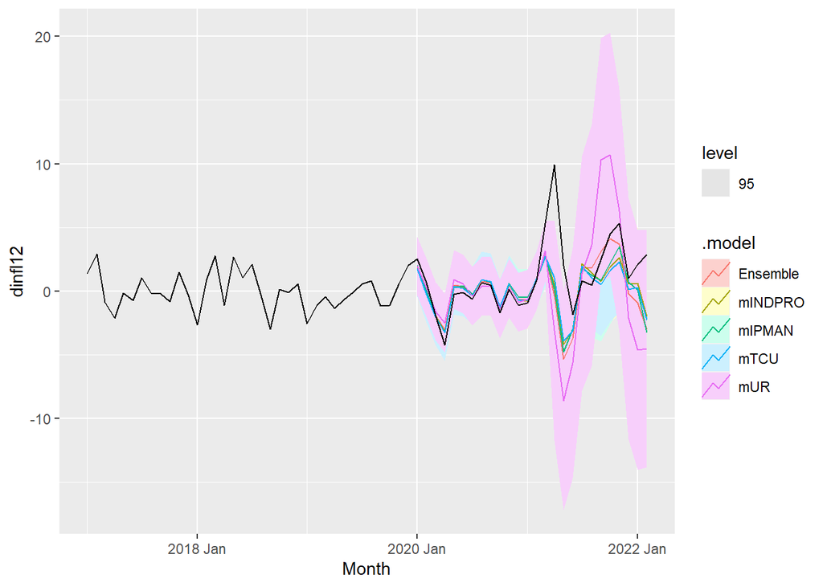

```r
FC_ALL %>% autoplot(filter(MODEL, year(Month) > 2016), level = c(95))
```